# Microbial Genomics 2025

November 20-22, 2025

# 1 Workshop Info

Welcome to the 2025 Microbial Genomics Canadian Bioinformatics Workshop webpage!

## 1.1 Pre-work

You can find your pre work here:

1. Please read **2023 CARD DB publication**.
2. Please read **2023 CARDShark publication**.
3. Please read **2025 Bait Capture VERSION 2 publication**.
4. Please read **2025 CARD k-mers pre-print**.
5. Please read **2025 CZ-ID publication**.
6. To participate in the live coding in Module 5, please read and follow the instructions at **Module 5 Pre-Work**.

## 1.2 Class Photo

Coming soon!

# 2 Meet Your Faculty

#### 2.0.0.1 Andrew McArthur

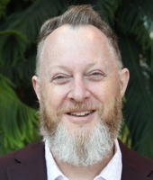

> Professor Michael G. DeGroote Institute for Infectious Disease Research Department of Biochemistry and Biomedical Sciences  
> McMaster University  
> Hamilton, ON, Canada

Dr. McArthur is a Professor and David Braley Chair in Computational Biology at McMaster University. Dr. McArthur has had a career in the United States and Canada, including NIH-funded positions at the Marine Biological Laboratory and Brown University, where he led the genome assembly of the diarrheal pathogen Giardia intestinalis, plus 10 years of experience in the private sector. Dr. McArthur’s research team focuses on building tools, databases, and algorithms for the genomic surveillance of infectious pathogens. He and his team developed the Comprehensive Antibiotic Resistance Database (card.mcmaster.ca) and the SARS-CoV-2 Illumina GeNome Assembly Line software platform

#### 2.0.0.2 Fiona Brinkman

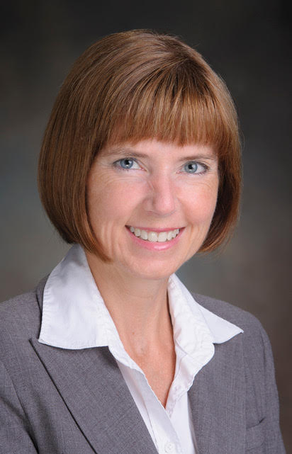

> Distinguished Professor, FRSC, Department of Molecular Biology and Biochemistry; Associate Member, School of Computing Science and Faculty of Health Sciences  
> Simon Fraser University  
> Burnaby, BC, Canada

> — brinkman@sfu.ca, https://www.brinkmanlab.ca/

Dr. Brinkman is developing bioinformatic resources to better track infectious diseases using genomic data, and improve prediction of new vaccine/drug targets. Her primary aim is to develop more sustainable, integrated approaches for infectious disease control, however she is also applying her methods to aid allergy, child health, and environmental research.

#### 2.0.0.3 Gary Van Domselaar

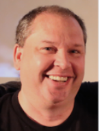

> Chief, Bioinformatics National Microbiology Laboratory  
> Public Health Agency of Canada  
> Winnipeg, MB, Canada

> gary.vandomselaar@phac-aspc.gc.ca

#### 2.0.0.4 Jared Simpson

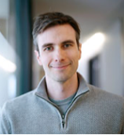

> Principal Investigator, Ontario Institute for Cancer Research Assistant Prof. Department of Computer Science, University of Toronto  
> Toronto, ON, Canada

> — https://simpsonlab.github.io/

Dr. Simpson develops algorithms and software for the analysis of high-throughput sequencing data. He is interested in de novo assembly and the detection of sequence variation in individuals, cancers and populations, with a focus on long read sequencing technologies. Dr. Simpson developed the ABYSS, SGA and nanopolish software packages.

#### 2.0.0.5 Jimmy Liu

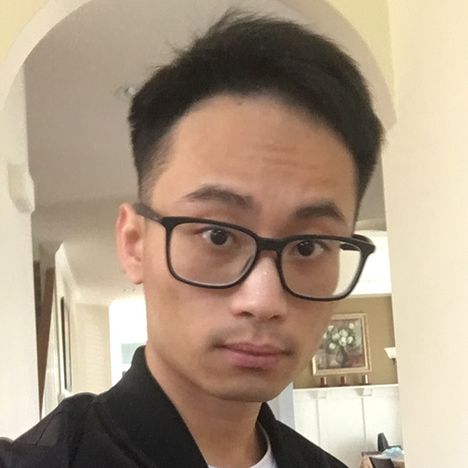

> PhD Candidate, Simon Fraser University  
> Burnaby, BC  
> Canada

> — ccl40@sfu.ca

Jimmy Liu is a PhD candidate trained in bioinformatics and biochemistry. He conducted his PhD research at Simon Fraser University focusing on the development of novel computational methods to enhance the utility of WGS data for enteric outbreak investigations and longitudinal surveillance. He also has years of experience working with nanopore long-read technologies in the context of veterinary diagnostics, such as expediting diagnostic turnaround times through real-time nanopore data analysis.

#### 2.0.0.6 Rob Beiko

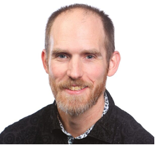

> Professor, Faculty of Computer Science  
> Dalhousie University  
> Halifax, NS, Canada

> — rbeiko@dal.ca

Rob Beiko is a professor in bioinformatics whose research encompasses microbial evolution and gene transfer, comparative genomics, and microbial community analysis. He is the lead of the ARETE project, which is developing a software pipeline for annotation of AMR and mobile genetic elements, phylogenomic analysis, and inference of recombination and transfer in large sets of pathogen genomes. He has also developed and contributed to software tools including STAMP for statistical analysis of metagenome profiles, rSPR for efficient inference of gene transmission, and PICRUSt for the prediction of metagenome composition based on marker-gene surveys.

#### 2.0.0.7 William Hsiao

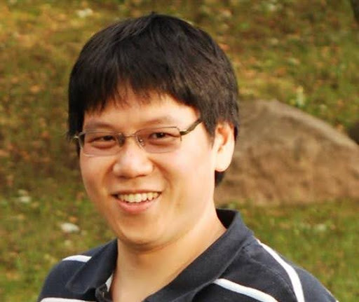

> Associate Professor, Faculty of Health Sciences  
> Simon Fraser University  
> Vancouver, BC, Canada — wwhsiao@sfu.ca, www.cidgoh.ca

William Hsiao is a public health infectious disease researcher with a background in microbial genomics and bioinformatics. He is an associate professor in the Faculty of Health Sciences at Simon Fraser University and an affiliated researcher at BCCDC Public Health Laboratory and at Canada’s Michael Smith Genome Sciences Centre. Will leads an interdisciplinary group of researchers interested in solving practical public health and animal health problems through a One Health lens at the Centre for Infectious Disease Genomics and One Health.

#### 2.0.0.8 Zhibin Lu

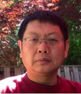

> Senior Manager, Digital Research  
> University Health Network  
> Toronto, ON, Canada — zhibin@gmail.com

Zhibin Lu is a senior manager at University Health Network Digital. He is responsible for UHN HPC operations and scientific software. He manages two HPC clusters at UHN, including system administration, user management, and maintenance of bioinformatics tools for HPC4health. He is also skilled in Next-Gen sequence data analysis and has developed and maintained bioinformatics pipelines at the Bioinformatics and HPC Core. He is a member of the Digital Research Alliance of Canada Bioinformatics National Team and Scheduling National Team.

#### 2.0.0.9 Charlie Barclay

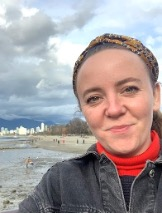

> MSc Graduate Student Researcher, Department of Physics and Astronomy  
> University of British Columbia  
> Vancouver, BC, Canada — cbarcl01@mail.ubc.ca

# 3 Data and Compute Setup

#### 3.0.0.1 Course data downloads

Coming soon!

#### 3.0.0.2 Compute setup

Coming soon!

# 4 Module 1 Microbial Genome Sequencing

## 4.1 Lecture

## 4.2 Lab

# 5 Module 2 Genome Assembly and Annotation

## 5.1 Lecture

## 5.2 Lab

# 6 Module 3 Mobile Genetic Elements

## 6.1 Lecture

## 6.2 Lab

# 7 Module 4 Antimicrobial Resistant Gene (AMR) Analysis

## 7.1 Lecture

## 7.2 Lab

# 8 Module 5 Pan Genomics

## 8.1 Lecture

## 8.2 Lab

# 9 Module 6 Phylogenetics

## 9.1 Lecture

## 9.2 Lab